# Analysis

aelhabr

Sat Feb 03 16:44:33 2018

# Tweet Volume

# Tweet Behavior

What proportion of tweets include more than just plain text (e.g. hashtags, links, etc.)? What proportion are not undirected, self-authored tweets (i.e. RTs or replies)?

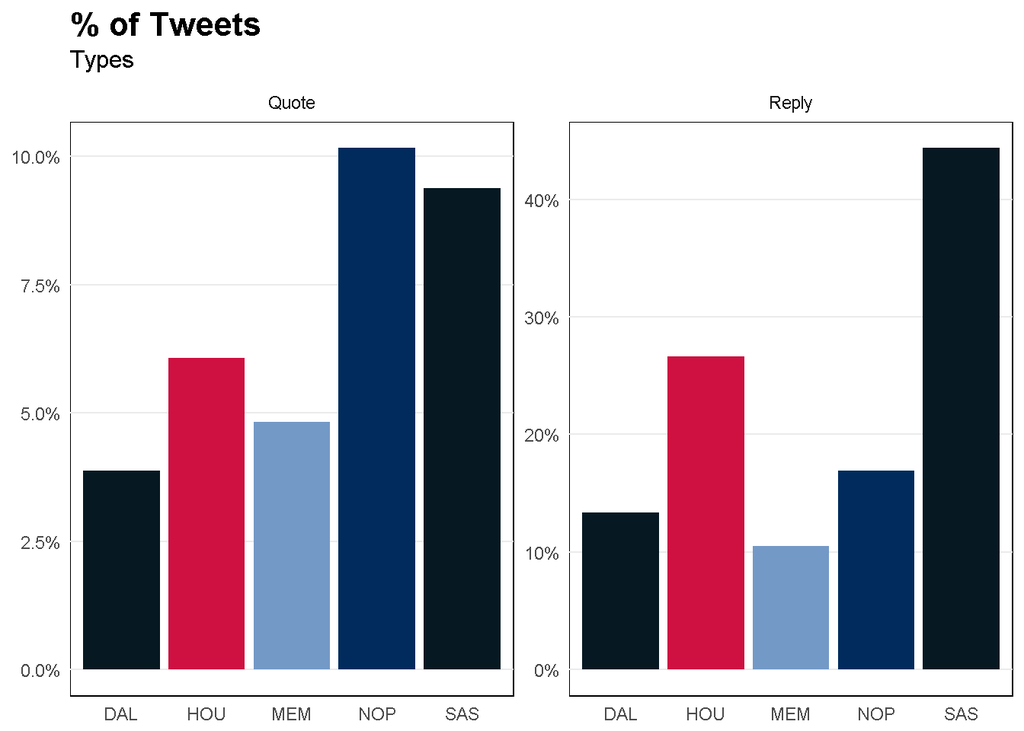

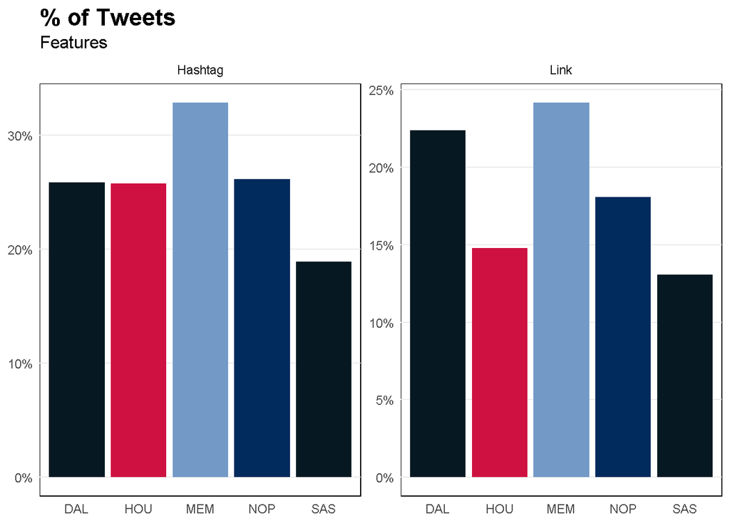

# Tweet Content

How long are the tweets?

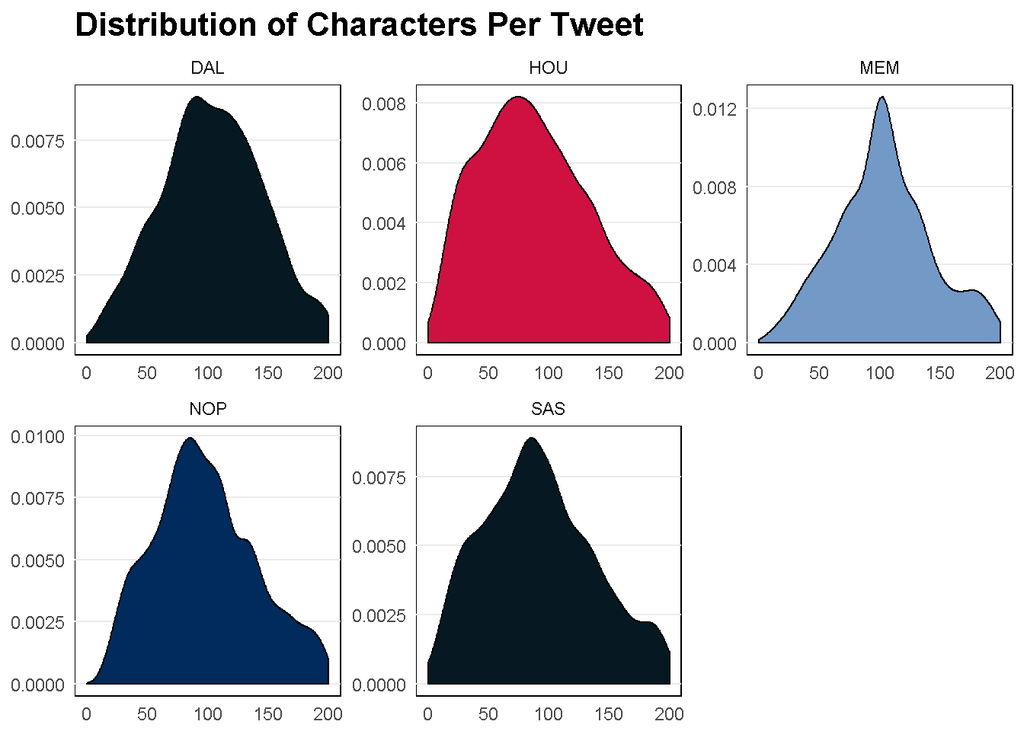

## Word Frequency and Usage

Which words are used most frequently?

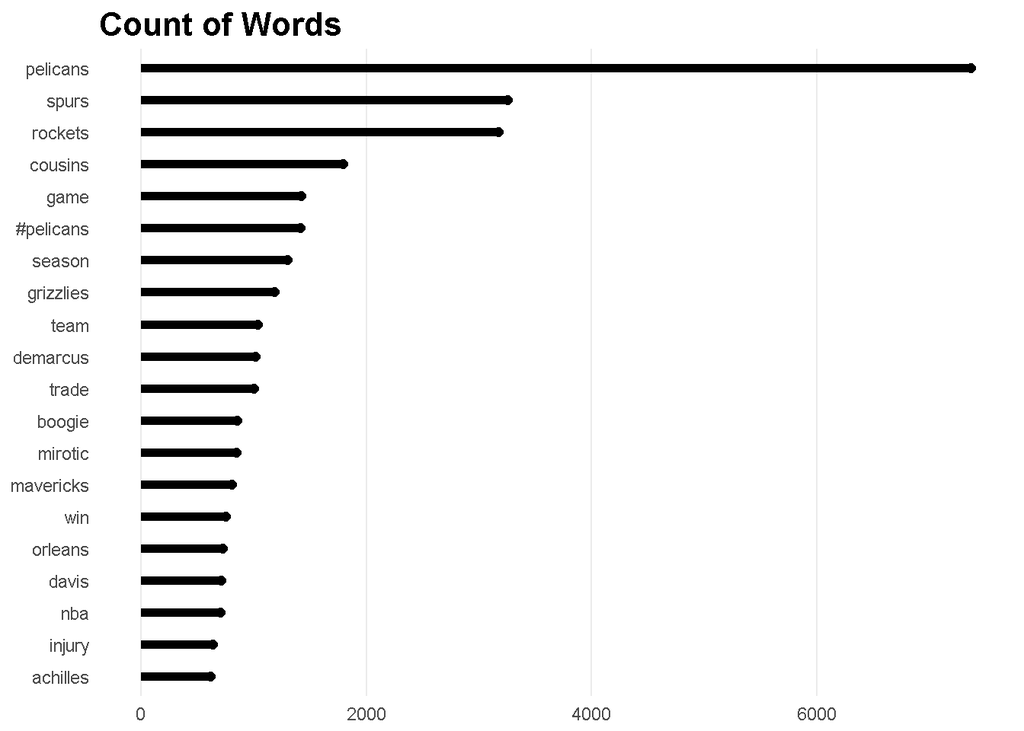

# A tibble: 10 x 6

name bigram n total freq rank 1 DAL “dallas” 118 4688 0.02517 1 2 DAL “dennis” 39 4688 0.008319 2 3 HOU “james” 162 12414 0.01305 1 4 HOU “houston” 108 12414 0.008700 2 5 MEM “blake” 156 6295 0.02478 1 6 MEM “memphis” 133 6295 0.02113 2 7 NOP “demarcus” 934 34895 0.02677 1 8 NOP “orleans” 514 34895 0.01473 2 9 SAS “bone” 482 13577 0.03550 1 10 SAS “cadet” 101 13577 0.007439 2

# A tibble: 10 x 6

name bigram n total freq rank 1 DAL “dallas” 118 4688 0.02517 1 2 DAL “dennis” 39 4688 0.008319 2 3 HOU “james” 162 12414 0.01305 1 4 HOU “houston” 108 12414 0.008700 2 5 MEM “blake” 156 6295 0.02478 1 6 MEM “memphis” 133 6295 0.02113 2 7 NOP “demarcus” 934 34895 0.02677 1 8 NOP “orleans” 514 34895 0.01473 2 9 SAS “bone” 482 13577 0.03550 1 10 SAS “cadet” 101 13577 0.007439 2

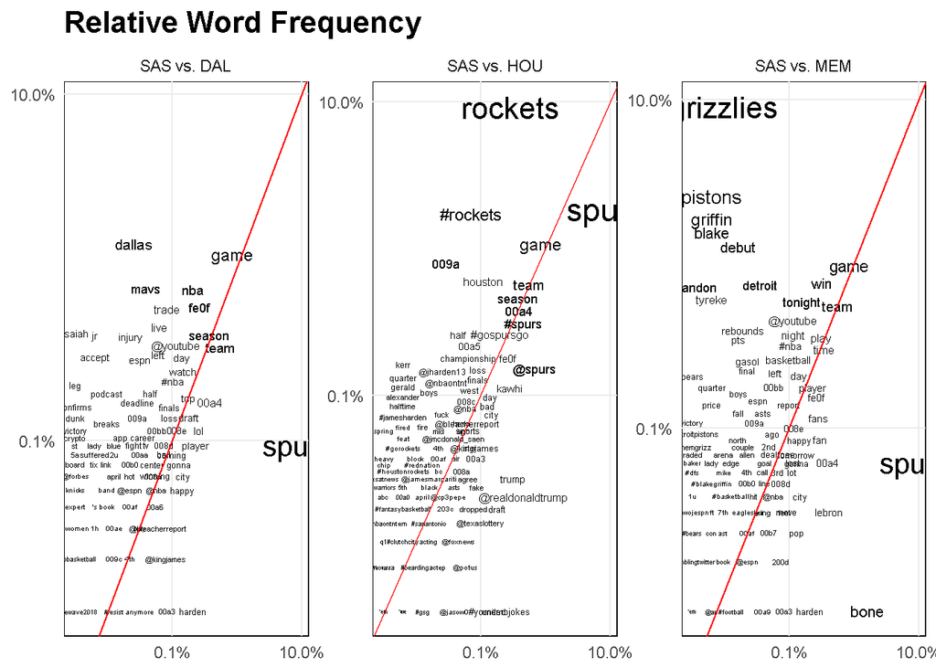

Which words are most likely to be used by one name compared to the other?

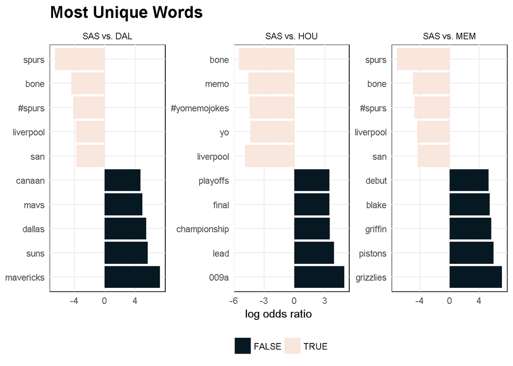

# Sentiment Analysis

What is the sentiment (i.e. “tone”) of the tweets?

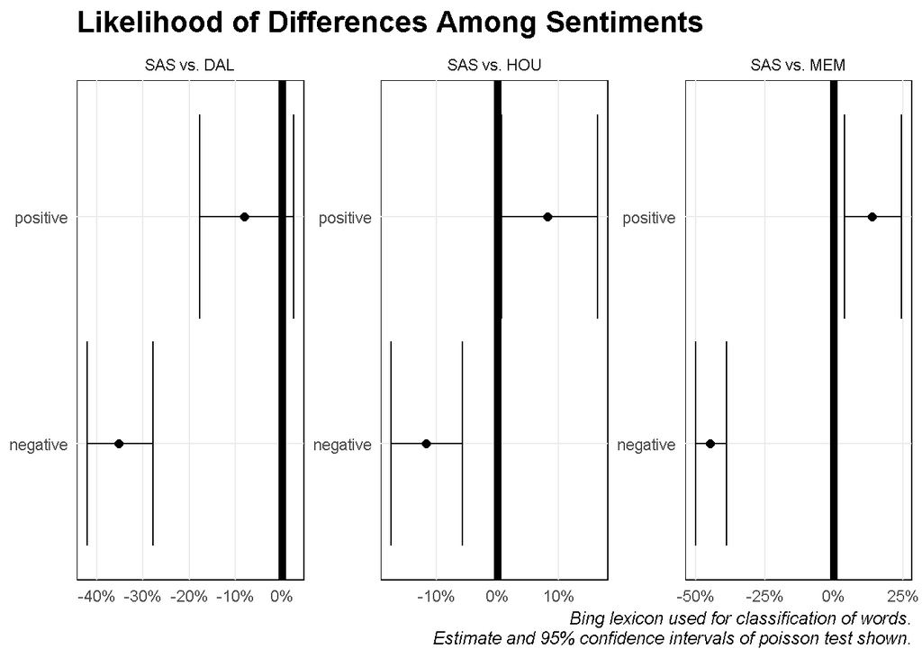

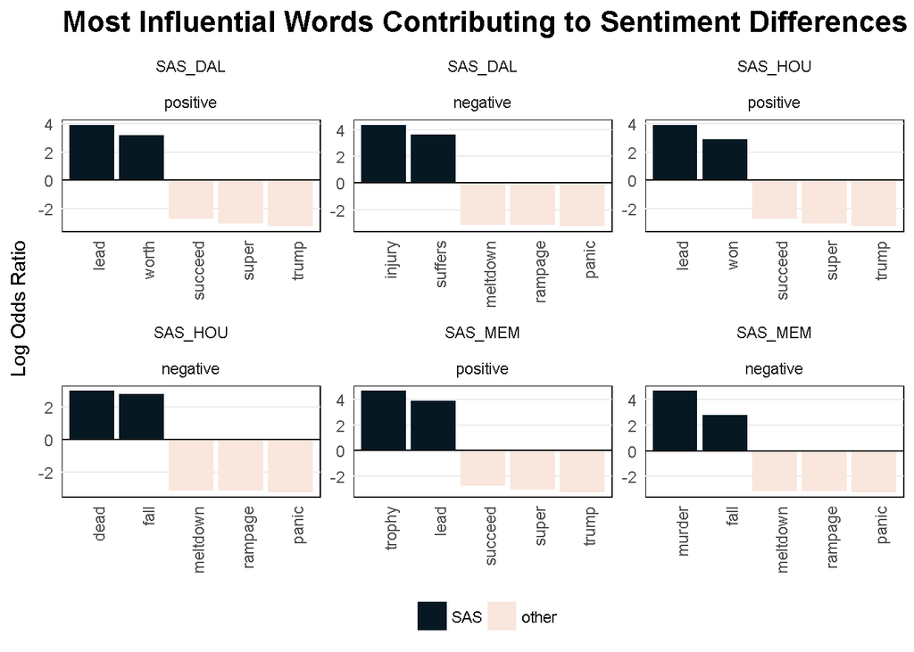

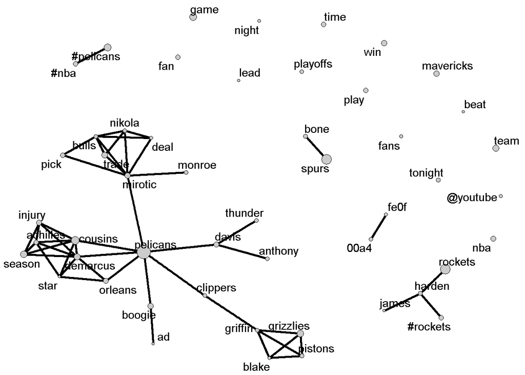